# snp_color_asso.R

xu

2021-01-19

## snp from table2 and table 3

- in table2 and table3 “rs10896418”, “rs10765819”,“rs9971729”,“rs1407995”,“rs12896399” are left blank for column skin color. blank means unknown.

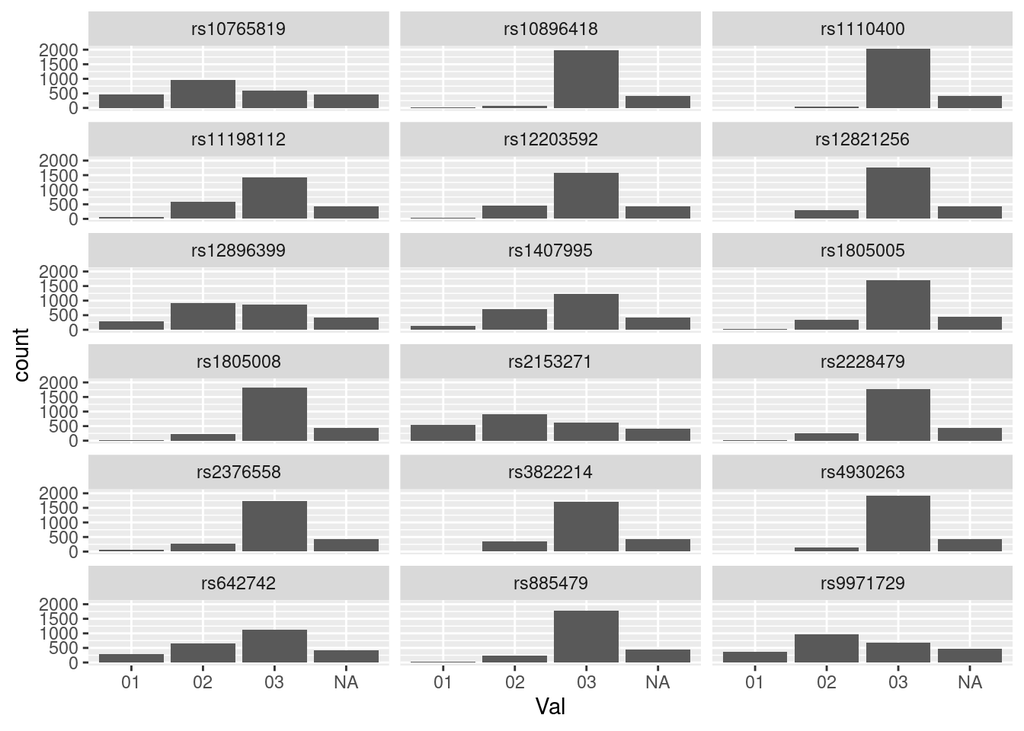

## multinomial regression: color_byinterviewer ~ snps, white as reference

### color_byinterviewer as a 3 category factor: White, LightMed, DarkBlack

```
## Analysis of Deviance Table (Type II tests)
##
## Response: color_byinterviewer3
##            LR Chisq Df Pr(>Chisq)
## rs3822214     7.491  4  0.1121159
## rs12203592   21.503  4  0.0002516 ***
## rs2153271    75.063  4  1.932e-15 ***
## rs11198112    9.024  4  0.0605036 .
## rs4930263    10.752  4  0.0295032 *
## rs2376558    31.004  4  3.056e-06 ***
## rs10896418    7.502  4  0.1116208
## rs10765819   15.599  4  0.0036071 **
## rs9971729    17.676  4  0.0014279 **
## rs642742    177.948  4  < 2.2e-16 ***
## rs12821256    8.821  4  0.0657446 .
## rs1407995     2.725  4  0.6048658
## rs12896399   54.098  4  5.019e-11 ***
## rs1805005     7.981  4  0.0922804 .
## rs2228479    28.880  4  8.270e-06 ***
## rs1110400     6.149  2  0.0462074 *
## rs1805008    20.288  4  0.0004382 ***
## rs885479      4.193  4  0.3805436
## ---
## Signif. codes:  0 '***' 0.001 '**' 0.01 '*' 0.05 '.' 0.1 ' ' 1
```

## skin color 3 level regression coefficient(only for significant snps, and taking the exponential of the original coefficient)

for example : $\displaystyle ln\left(\frac{P(skin color = DarkBlack)}{P(skin color = White)}\right) = b_{0} + b_{1}(snp=02) + b_{2}(snp=03)$ taking exponential of both sides $\displaystyle \frac{P(skin color = DarkBlack)}{P(skin color = White)} = exp^\left(b_{0} + b_{1}(snp=02) + b_{2}(snp=03)\right)$ switching from snprs12203592=01 to snprs12203592=02, the odds for being darkblack vs. white is 2.148585e+09

|  | DarkBlack | LightMed |
| --- | --- | --- |
| rs12203592_02 | 2.148585e+09 | 6.925819e+08 |
| rs12203592_03 | 7.461470e+09 | 1.609484e+09 |
| rs2153271_02 | 9.409783e+00 | 1.853091e+00 |
| rs2153271_03 | 3.362164e+01 | 4.749633e+00 |
| rs4930263_02 | 0.000000e+00 | 0.000000e+00 |
| rs4930263_03 | 0.000000e+00 | 0.000000e+00 |
| rs2376558_02 | 1.391556e+00 | 1.951015e+00 |
| rs2376558_03 | 3.291181e-01 | 3.012778e-01 |
| rs10765819_02 | 2.289773e+00 | 1.025128e+00 |
| rs10765819_03 | 4.098543e+00 | 1.555492e+00 |
| rs9971729_02 | 1.866542e+00 | 1.864548e+00 |
| rs9971729_03 | 2.997682e+00 | 2.958051e+00 |
| rs642742_02 | 9.630430e-02 | 1.293066e-01 |
| rs642742_03 | 1.269720e-02 | 6.736090e-02 |
| rs12896399_02 | 5.210285e+00 | 2.591965e+00 |
| rs12896399_03 | 1.718117e+01 | 5.301696e+00 |
| rs2228479_02 | 8.408609e+07 | 1.209742e-01 |
| rs2228479_03 | 7.826257e+08 | 3.059913e-01 |
| rs1110400_03 | 3.327036e+13 | 1.436231e+00 |
| rs1805008_02 | 1.613048e+03 | 2.395264e+10 |
| rs1805008_03 | 1.263397e+04 | 9.157644e+10 |

### color_byinterviewer as a 5 category factor: white, light brown, medium brown, dark brown, black

```
## Analysis of Deviance Table (Type II tests)
##
## Response: color_byinterviewer5
##            LR Chisq Df Pr(>Chisq)
## rs3822214     9.075  8  0.3359878
## rs12203592   25.692  8  0.0011854 **
## rs2153271    83.249  8  1.082e-14 ***
## rs11198112   11.264  8  0.1871902
## rs4930263    10.642  8  0.2227932
## rs2376558    32.915  8  6.381e-05 ***
## rs10896418   15.529  8  0.0496363 *
## rs10765819   30.023  8  0.0002094 ***
## rs9971729    21.037  8  0.0070491 **
## rs642742    208.895  8  < 2.2e-16 ***
## rs12821256   11.419  8  0.1790840
## rs1407995     5.357  8  0.7188411
## rs12896399   58.888  8  7.698e-10 ***
## rs1805005    10.658  8  0.2218679
## rs2228479    34.448  8  3.370e-05 ***
## rs1110400     6.009  4  0.1984488
## rs1805008    20.315  8  0.0092094 **
## rs885479     15.450  8  0.0509565 .
## ---
## Signif. codes:  0 '***' 0.001 '**' 0.01 '*' 0.05 '.' 0.1 ' ' 1
```

## skin color 5 level regression coefficient(only for significant snps, and taking the exponential of the original coefficient)

for example : $\displaystyle ln\left(\frac{P(skin color = Black)}{P(skin color = White)}\right) = b_{0} + b_{1}(snp=02) + b_{2}(snp=03)$ taking exponential of both sides $\displaystyle \frac{P(skin color = Black)}{P(skin color = White)} = exp^\left(b_{0} + b_{1}(snp=02) + b_{2}(snp=03)\right)$

|  | Black | Dark | Medium | Light |
| --- | --- | --- | --- | --- |
| rs12203592_02 | 1314.5989523 | 5.360630e+03 | 2.812778e+04 | 1.113903e+05 |
| rs12203592_03 | 7889.5257601 | 1.635299e+04 | 1.130233e+05 | 1.905973e+05 |
| rs2153271_02 | 1650.1471945 | 5.870225e+00 | 4.734702e+00 | 1.277252e+00 |
| rs2153271_03 | 6337.3976191 | 1.998779e+01 | 1.188557e+01 | 3.301330e+00 |
| rs2376558_02 | 1.0323563 | 1.699049e+00 | 1.889091e+00 | 1.756687e+00 |
| rs2376558_03 | 0.2463484 | 3.031506e-01 | 2.251124e-01 | 2.965797e-01 |
| rs10896418_02 | 0.0000003 | 6.715620e-02 | 8.410673e+03 | 1.191451e-01 |
| rs10896418_03 | 40.3779706 | 1.064802e-01 | 8.082716e+03 | 9.719970e-02 |
| rs10765819_02 | 2.1526291 | 3.635356e+00 | 2.640142e+00 | 7.132127e-01 |
| rs10765819_03 | 4.3066048 | 6.574074e+00 | 4.404658e+00 | 9.505416e-01 |
| rs9971729_02 | 2.3311470 | 2.097346e+00 | 2.988318e+00 | 1.467982e+00 |
| rs9971729_03 | 3.1491441 | 3.982956e+00 | 4.861031e+00 | 2.199065e+00 |
| rs642742_02 | 0.0916833 | 8.287990e-02 | 1.041409e-01 | 1.756523e-01 |
| rs642742_03 | 0.0097019 | 1.105310e-02 | 1.910630e-02 | 1.519627e-01 |
| rs12896399_02 | 4.3469361 | 6.767892e+00 | 1.976090e+00 | 2.865957e+00 |
| rs12896399_03 | 14.4965545 | 2.809026e+01 | 6.169811e+00 | 4.490425e+00 |
| rs2228479_02 | 0.0133176 | 1.092929e+04 | 1.794887e-01 | 1.009856e-01 |
| rs2228479_03 | 323.6793560 | 5.926951e+04 | 4.440800e-01 | 2.632289e-01 |
| rs1805008_02 | 10.6302821 | 3.243550e+00 | 3.196663e+02 | 3.206090e+04 |
| rs1805008_03 | 55.8309845 | 4.789664e+01 | 1.515484e+03 | 1.031117e+05 |